# **Hito 1.** Análisis de canciones: Lo que suena vs. Lo que dice.

## Proyecto Minería de Datos

Integrantes:

- Benjamín Aguilar.
- Benjamín Alvial.
- Diego Carmona.
- Jules Fredes C.
- Diego Reyes.

## 1. Introducción

La música es una vía de expresión del ser humano y nunca ha dejado de estar presente. Considerando esto, resulta interesante conocer si existe una relación entre características de canciones y el periodo de tiempo en el que fueron creadas. Esta relación puede ser técnica y se podrían estudiar aspectos como la duración, el volumen, el uso de instrumentos, entre otros. Considerando a la música como vía de expresión, resulta aún más interesante estudiar relaciones entre el periodo de creación y los sentimientos que las canciones expresan, que podrían representarse mediante los temas que las letras tocan. Es quizá posible que, en periodos de crisis humanas, las canciones tengan aspectos técnicos y emocionales que vislumbren temas de desánimo. Asimismo, podría ser que haya aspectos tan transversales a la vida humana que se presentan en todo periodo del tiempo, independiente del contexto mundial.

Por otro lado, el ser humano se dedica a clasificar lo que sea que exista, incluyendo la música. Por ello, es interesante estudiar la categorización que el mismo ser humano ha creado - el género. Es común pensar que las canciones se definen en términos de género por la forma en que suenan más que de lo que hablan. Por lo tanto, se puede estudiar si esta hipótesis es certera, analizando aspectos técnicos para el sonido y las letras de las canciones para los temas de los que tratan.

## 2. Exploración de datos

### Sobre el conjunto de datos

El conjunto de datos se encuentra disponible en: https://www.kaggle.com/datasets/saurabhshahane/music-dataset-1950-to-2019

```python
import pandas as pd
df = pd.read_csv(r'C:\Users\benja\Desktop\Mineria de Datos\Hito 1\datos.csv')
df_real = df[['Unnamed: 0', 'track_name', 'release_date', 'genre', 'lyrics', 'len', 'danceability', 'loudness', 'acousticness', 'instrumentalness', 'valence', 'energy']]
```

El conjunto de datos, filtrado para el propósito del proyecto, tiene un total de 28.372 canciones. Para cada una de ellas, se tienen los siguientes atributos: 'track_name' (nombre), 'release_date' (año), 'genre' (género), 'lyrics' (letra) , 'len' (duración), 'danceability' (bailiabilidad), 'volumen' (volumen), 'acousticness' (acústica), 'instrumentalness' (instrumentalidad), 'valence' (valencia), 'energy' (energía).

```python
df_real.shape
```

```
(28372, 12)
```

```python
df_real.info()
```

```
<class 'pandas.core.frame.DataFrame'>
RangeIndex: 28372 entries, 0 to 28371
Data columns (total 12 columns):
 #   Column            Non-Null Count  Dtype
---  ------            --------------  -----
 0   Unnamed: 0        28372 non-null  int64
 1   track_name        28372 non-null  object
 2   release_date      28372 non-null  int64
 3   genre             28372 non-null  object
 4   lyrics            28372 non-null  object
 5   len               28372 non-null  int64
 6   danceability      28372 non-null  float64
 7   loudness          28372 non-null  float64
 8   acousticness      28372 non-null  float64
 9   instrumentalness  28372 non-null  float64
 10  valence           28372 non-null  float64
 11  energy            28372 non-null  float64
dtypes: float64(6), int64(3), object(3)
memory usage: 2.6+ MB
```

Las dos variables principales a analizar son el año y el género, que se intentarán relacionar con la letra y con los atributos técnicos.

```python
df_real.head()
```

|  | Unnamed: 0 | track_name | release_date | genre | lyrics | len | danceability | loudness | acousticness | instrumentalness | valence | energy |
| --- | --- | --- | --- | --- | --- | --- | --- | --- | --- | --- | --- | --- |
| 0 | 0 | mohabbat bhi jhoothi | 1950 | pop | hold time feel break feel untrue convince spea... | 95 | 0.357739 | 0.454119 | 0.997992 | 0.901822 | 0.339448 | 0.137110 |
| 1 | 4 | i believe | 1950 | pop | believe drop rain fall grow believe darkest ni... | 51 | 0.331745 | 0.647540 | 0.954819 | 0.000002 | 0.325021 | 0.263240 |
| 2 | 6 | cry | 1950 | pop | sweetheart send letter goodbye secret feel bet... | 24 | 0.456298 | 0.585288 | 0.840361 | 0.000000 | 0.351814 | 0.139112 |
| 3 | 10 | patricia | 1950 | pop | kiss lips want stroll charm mambo chacha merin... | 54 | 0.686992 | 0.744404 | 0.083935 | 0.199393 | 0.775350 | 0.743736 |
| 4 | 12 | apopse eida oneiro | 1950 | pop | till darling till matter know till dream live ... | 48 | 0.291671 | 0.646489 | 0.975904 | 0.000246 | 0.597073 | 0.394375 |

```python
pd.Series(' '.join(df_real['lyrics']).split()).value_counts()[:10]
letras = df_real['lyrics']
```

### Análisis temporal

La distribución de las canciones por año es como se muestra a continuación. Nuevamente, se tendrá que tener cuidado con manejar las canciones antes de los años 60.

```
array([[<AxesSubplot:title={'center':'release_date'}>]], dtype=object)
```

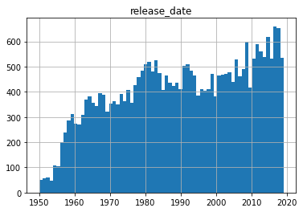

```python
max = df_real['release_date'].max()
min = df_real['release_date'].min()
df_real.hist('release_date', bins=max-min+1)
```

A priori se ve que con el tiempo las canciones han aumentado su duración, valoumen energía y disminuido su acústica, pero es difícil analizar cuando las clases están muy desbalanceadas (pocos datos en años tempranos).

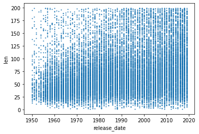

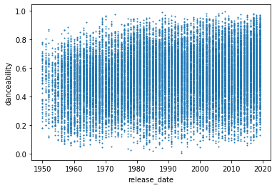

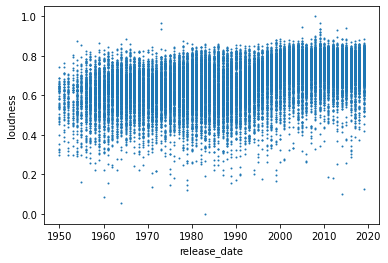

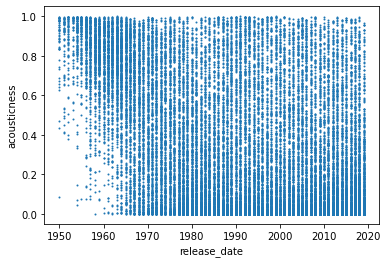

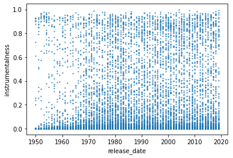

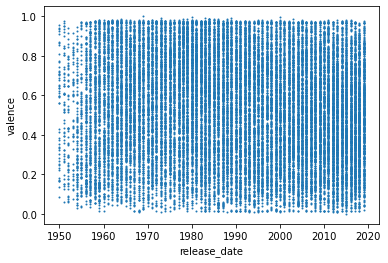

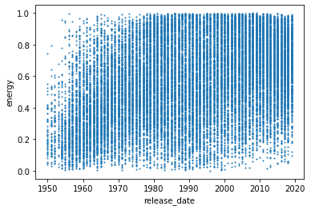

```python
for aspecto in ['len', 'danceability', 'loudness', 'acousticness', 'instrumentalness', 'valence', 'energy']:
  df_real.plot.scatter(x='release_date', y=aspecto, s=1)
```

No se ve una tendencia muy clara en palabras utilizadas en cada década. Tampoco cuando se desagrega por año (no se muestra por simplicidad).

```python
for i in range(1950, 2010, 10):
  print(i, '...')
  copy = df_real[(df_real.release_date>=i) & (df_real.release_date<=i+9)]
  print(pd.Series(' '.join(copy['lyrics']).split()).value_counts()[1:5])
  print('---')
```

```
1950 ...
heart    1078
like     1004
come      956
time      932
dtype: int64
---
1960 ...
time     2557
come     2476
heart    2335
like     2191
dtype: int64
---
1970 ...
time    3915
come    3155
like    2856
go      2646
dtype: int64
---
1980 ...
time     4493
like     4151
come     3770
heart    3587
dtype: int64
---
1990 ...
like    4715
time    4276
come    3905
feel    2764
dtype: int64
---
2000 ...
like    5844
time    4707
come    4207
away    3251
dtype: int64
---
```

### Análisis de género

La distribución de las canciones por género es como se muestra a continuación. Es algo que se debe tener en cuenta, pues las clases no están del todo balanceadas.

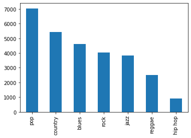

```python
import matplotlib.pyplot as plt
fig, ax = plt.subplots()
df_real['genre'].value_counts().plot(ax=ax, kind='bar')
```

Con respecto al género relacionado con los ámbitos técnicos, a priori no se visualizan relaciones concretas. Es posible, sin embargo, que la agregación de todos los aspectos sí den indicios de uno u otro género.

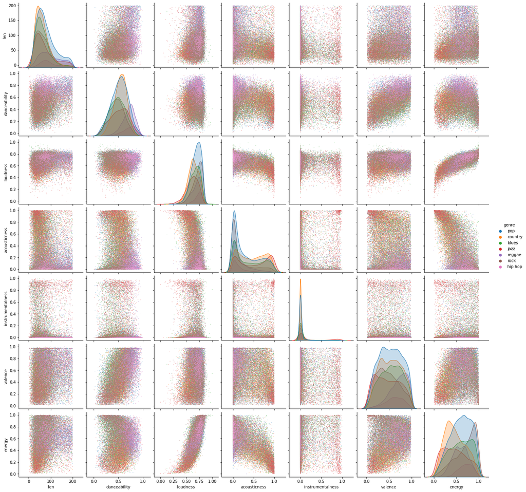

```python
import seaborn as sns
sns.pairplot(df_real, vars=['len', 'danceability', 'loudness', 'acousticness', 'instrumentalness', 'valence', 'energy'], hue='genre', plot_kws={"s": 1})
```

Se pueden ver las palabras más comunes por género. A priori es difícil encontrar palabras muy distintivas, salvo en casos como el hip hop.

```python
for i in df_real.genre.unique():
  print(i, '...')
  copy = df_real[(df_real.genre==i)]
  print(pd.Series(' '.join(copy['lyrics']).split()).value_counts()[:5])
  print('--')
```

```
pop ...
know    9983
like    8349
time    6982
come    6304
yeah    5365
dtype: int64
--
country ...
know     5836
time     5230
like     4569
heart    4460
come     3900
dtype: int64
--
blues ...
know    4959
time    3945
like    3699
come    3677
baby    3382
dtype: int64
--
jazz ...
like    4017
know    3931
time    3470
come    2936
life    2217
dtype: int64
--
reggae ...
like    3790
know    3577
come    2951
time    2830
yeah    2492
dtype: int64
--
rock ...
know    3878
time    3471
like    3094
come    3036
away    2936
dtype: int64
--
hip hop ...
like     2131
know     1362
come      815
cause     799
nigga     776
dtype: int64
--
```

## 3. Preguntas y problemas

Dada la exploración de datos realizada y el contexto de los datos, es posible desarrollar las siguientes preguntas y problemas:

Las canciones desarrolladas en un cierto periodo temporal en la historia ¿tienen características técnicas y/o emocionales que sean distintivas de dicho periodo?

- Problema de clasificación: Generar un modelo que pueda predecir la década o año de una canción basándose en sus aspectos técnicos como bailabilidad, volumen, energía, entre otros.
- Problema de clasificación: Generar un modelo que pueda predecir la década o año de una canción basándose en sus aspectos expresivos como los títulos y las letras de la canciones.

Puede ser útil resolver estos problemas pues permitiría aproximarse a saber qué tan estable es la música a lo largo del tiempo. Quizá se podría estudiar la posible existencia de tendencias que permitan predecir la forma en que se creará música en el futuro cercano.

¿El género de una canción está más ligado a la verbalización o al sonido de una canción?

- Problema de clasificación: Generar un modelo que pueda predecir el género de una canción basándose en los aspectos técnicos como bailabilidad, volumen, energía, entre otros.
- Problema de clasificación: Generar un modelo que pueda predecir el género de una canción basándose en las palabras contenidas en la letra de ella.

Luego, se puede comparar el éxito de ambos modelos para aproximarse a responder cuál de los dos es más determinante para clasificar un género.

## 4. Contribuciones de integrantes

- Redacción de introducción: Benjamín Alvial
- Programación para exploración de datos: Benjamín Alvial
- Formulación de preguntas y problemas: Benjamín Aguilar y Benjamín Alvial
- *Proofreading*: Jules Fredes C.